# Final Exam

STA 235H

Due on Dec. 5th, 11:59pm

# Note

- This document will serve as your Answer Key for the Final Exam. Please check the rubric to understand how the assignment is graded.
- All automatically-graded questions will receive full credit if correct or 0 points if they are not correct. The only exception is with multiple answers were points are allocated proportionally.
- Inconsistencies between code and answers will be discounted (i.e. if an answer is correct, but the code used to get to that answer is not, that question will be discounted).
- R scripts will also be checked for completeness and accuracy. If they are not complete (i.e. do not contain the code/output requested) or answers don’t match your Canvas submission, a discount will apply.
- After you receive your graded exam, you will have one week to submit re-grading requests. Please compare your graded submission with this answer key and fill out the re-grading form with your specific request.

# Task 1 - Conceptual Questions

**1.1) Thinking of linear models and regressions, which of the following statements is/are TRUE?**

1. In a linear regression, the intercept captures the average outcome of my sample.
2. In a simple regression ($Y = \beta+0 + \beta_1X + \varepsilon$), $\beta_1$ represents the average change in $Y$ when $X$ increases in one unit.
3. A linear regression with a binary outcome is referred to as a linear probability model.
4. In a linear regression with a quadratic term ($Y = \beta_0 + \beta_1X + \beta_2X^2+\varepsilon$), the term ($2\beta_1 + \beta_2X_0$) represents the average change in $Y$ when $X$ increases from $X_0$ to $X_0+1$.

Answer:

B and C

**1.2) Thinking about ensemble methods, which of the following statements is/are TRUE?**

1. Given that in bagging we aggregate trees, aggregating a very large number of trees could yield an overfitted model.
2. In general, compared to bagging trees, random forests reduce bias by selecting a subset of predictors.
3. Given that in boosting we aggregate trees, aggregating a very large number of trees could yield an overfitted model.
4. In a model with p predictors, if the number of randomly selected predictors is p, then random forest will perform the same as bagging.

Answer:

C and D

**1.3) Thinking about differences-in-differences, which of the following statements is/are TRUE?**

1. In a differences-in-differences setting, like in an RCT, we should build a balance table to assess whether our groups are balanced.
2. For the ignorability assumption to hold in a differences-in-differences setting, both the treatment and the control group need to be comparable in terms of unobserved confounders.
3. A robustness check we can conduct in a differences-in-differences analysis is comparing the trends between treatment and control groups before the intervention takes place.
4. In differences-in-differences we assume that, in the absence of the intervention, both the treatment and the control group should have the same trend.

Answer:

C and D

**1.4) In this example we are looking at sales data for a retail store. Specifically, we are predicting the amount an individual purchases (sales) based on their gender, age, and income. Looking at the following tree, what is the predicted outcome for a female age 34 with an income of $130,000**

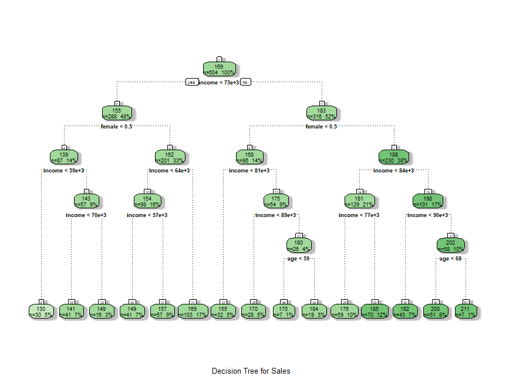

Answer:

200

**1.5) Looking at this equation, where we are explaining someone’s salary based on their years of education (Educ), years of experience (Exp), and their family income:**

$$\log\left(Salary\right)=\beta_0+\beta_1Educ+\beta_2Exp+\beta_3Exp^2+\beta_4\log\left(FamilyIncome\right)+\varepsilon$$

**Which of the following statements is/are TRUE?**

1. Salary and Experience will have a positive correlation (holding other variables constant) if $\beta_2>0$
2. For a 1% increase in family income, salary increases, on average, by $\beta_4$%, holding other variables constant.
3. $\beta_1$ captures the average change in Salary when education increases in one year.
4. Increasing experience from 2 to 3 years increases salary, on average, by $(\beta_2+4\beta_3)\times100$%, holding education and family income constant.

**1.6) Interpret $\beta_1$ in the following equation:**

$$Vote=\beta_0+\beta_1Education+\beta_2DemState+\beta_3Education\times
DemState+\varepsilon$$
**Where Vote is a binary variable for whether someone voted (1) or not (0) in the last election, Education captures the individual’s years of education, and DemState is a binary variable that captures whether the person lives in a state with a democratic majority (1) vs a republican majority (0).**

**The results for the equation are as following:**

$\beta_0=0.31$

$\beta_1=0.013$

$\beta_2=0.092$

$\beta_3=0.005$

Answer:

On average, one additional year of education is associated with a 1.3 percentage point increase in the probability of voting, for individuals living in a Republican leaning state.

**or**

On average, one additional year of education is associated with a 0.013 increase in the probability of voting, for an individual living in a Republican leaning state)

- 4 points: (i) Uses “on average”, (ii) estimate and units are correct (percentage points OR probability), (iii) identifies the association for individuals in Republican leaning states, and (iv) doesn’t compare it with individuals in democratic states. Also, (v) doesn’t say “holding other variables constant”.
- 2 points: One of the previous items is incorrect.
- 0 points: Any other case.

# Task 2 - Empowering women

Many countries have adopted policies or interventions to help advance women empowerment in politics. One of those countries is India, where since the mid-1990’s one-third of Head Council positions have been randomly reserved for women. The Head Council is in charge of the provision of different public goods in villages, especially in rural areas, such as irrigation and water sources. **We want to assess the effect on the provision of these services between areas that had reserved positions for women and those that did not**.

To accomplish this task, we will be using data from Chattopadhyay and Duflo (2004). You can find the data here:

```r
women <- read.csv("C:/Users/mc72574/Dropbox/UT/Teaching/2022Fall_STA235H/Final/data/women.csv")
```

The variables in the dataset are the following:

- `GP`: Identifier for the Gram Panchayat (Village Council)
- `village`: Identifier for each village
- `reserved`: Binary variable indicating whether the GP was reserved for women leaders or not.
- `female`: Binary variable indicating whether the GP had a female leader or not.
- `irrigation`: Variable measuring the number of new or repaired irrigation facilities in the village since the reserve policy started.
- `water`: Variable measuring the number of new or repaired drinking water facilities in the village since the reserve policy started.

**2.1) According to the previous description, what is your treatment variable?**

Answer:

`reserved`

**2.2a) Run a simple regression between `water` and your treatment variable. What is the coefficient of interest?**

Answer:

```r
summary(lm(water ~ reserved, data = women))
```

```
##
## Call:
## lm(formula = water ~ reserved, data = women)
##
## Residuals:
##     Min      1Q  Median      3Q     Max
## -23.991 -14.738  -7.865   2.262 316.009
##
## Coefficients:
##             Estimate Std. Error t value Pr(>|t|)
## (Intercept)   14.738      2.286   6.446 4.22e-10 ***
## reserved       9.252      3.948   2.344   0.0197 *
## ---
## Signif. codes:  0 '***' 0.001 '**' 0.01 '*' 0.05 '.' 0.1 ' ' 1
##
## Residual standard error: 33.45 on 320 degrees of freedom
## Multiple R-squared:  0.01688,    Adjusted R-squared:  0.0138
## F-statistic: 5.493 on 1 and 320 DF,  p-value: 0.0197
```

**2.2b) Is the previous coefficient statistically significant at conventional levels?**

Answer:

Yes

**2.2c) Interpret the coefficient in 2.2a) in the context of this experiment.**

Answer:

On average, having a GP position reserved for women increases the number of new or repaired water facilities in villages by 9.3 compared to villages that do not have a reserved GP seat for women.

- 5 points: (i) Uses “on average”, (ii) identifies the treatment correctly (reserved positions), and (iii) compares it to the control (not having reserved positions). (iv) Units are correct (number of facilities), and (v) doesn’t say “holding other variables constant”.
- 3 points: One of the previous items is incorrect.
- 1 point: Two of the previous items are not correct
- 0 points: Any other case.

**2.3) Thinking about this example, we could also look at data in other countries to assess the effectiveness of female representatives over male representatives. Suppose that we have data in the US to run the following regression:**

$$CrimeRate=\beta_0+\beta_1FemaleMayor+\beta_2CityBudget+\beta_3Population+\beta_4State+\varepsilon$$
**Where `CrimeRate` captures the crime rate in a city. We adjust by the budget City Hall has, population in the city, and also control by state, and we get the following results:**

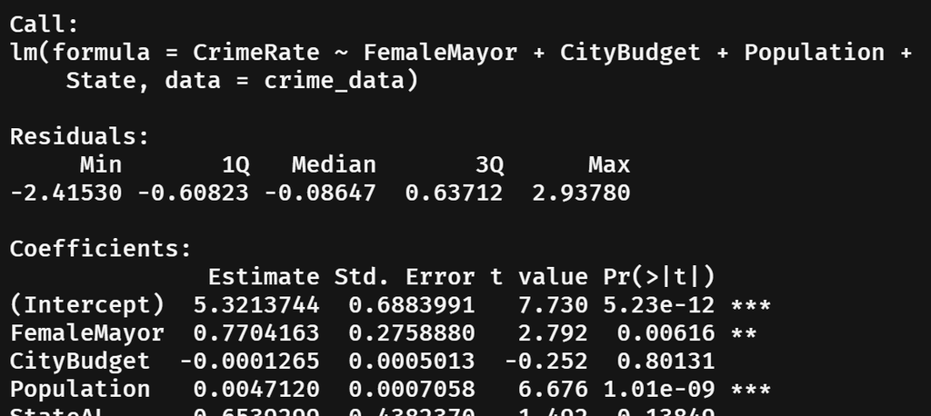

**Do you think $\beta_1$ represents a causal effect? Why or why not? Be specific and provide an example.**

Answer:

No, the coefficient for `FemaleMayor` does not capture a causal effect because there could be other unobserved confounders that we might not be taking into account. For example, how liberal/conservative a city is could affect the probability of having a female elected mayor. At the same time, how a city leans politically could also affect the laws/budget allocations that are in effect (e.g. funding for police) that also have an impact on crime rate.

- 8 points: (i) Identifies is not a causal effect, (ii) identifies a specific unobserved confounding variable (not included in the model), and (iii) clearly draws the effect between the confounder and the probability of treatment (having a female Mayor) and the outcome (crime rate).
- 6 points: (i) and (ii) are correct, but doesn’t include direct effect between confounder/treatment or confounder/outcome.
- 5 points: (i) and (ii) are correct, but doesn’t provide any examples of how it affects both the treatment and outcome.
- 3 points: (i) is correct and identifies potential selection bias/confounding, but (i) provides an incorrect confounder (not clear how it affects both treat and outcome) or (ii) includes an outcome that we are already controlling for.
- 1 point: Says it not causal but doesn’t provide an explanation.
- 0 points: Any other case.

# Task 3 - Vacation time!

You are currently working at a company that offers vacation packages for customers, and have been asked to improve your targeting strategy. Currently, associates have a list of clients and they call them to offer them distinct packages, without taking into account the client’s characteristics. Given that you have this information, you think it would be useful to run a prediction model to better target the characteristics of clients that are more likely to say yes to specific packages.

You have the following data on offers:

```r
travel <- read.csv("https://raw.githubusercontent.com/maibennett/presentations/main/content/data/travel.csv")
```

The objective of this task is to predict whether a consumer purchases a package (`ProdTaken`) or not.

For all models, you will need to use a seed 123 and a cross-validation approach with 10 folds. Remember to set a seed before running any line of code that contains any “randomness”.

**3.1) First, let’s create a training and a testing dataset. Use 70% of the data for training and 30% for testing (name your datasets `train.data` and `test.data` respectively), randomly partition your data stratifying by the outcome of interest. What is the proportion (0-1) of female customers that you have in your testing dataset?** (4 points)

Answer:

```r
library(rsample)
library(tidyverse)
library(caret)

set.seed(123)

split <- initial_split(travel, prop = 0.7, strata = "ProdTaken")

train.data <- training(split)
test.data <- testing(split)

test.data %>% select(Gender) %>% table(.) %>% prop.table(.)
```

```
## Gender
##    Female      Male
## 0.3497268 0.6502732
```

**3.2a) Fit a random forest with 100 trees, and only tune for the random number of chosen predictors. Insert your code here:**

Answer:

```r
lm_all <- lm(ProdTaken ~ . - CustomerID, data = travel)
nvars <- length(lm_all$coefficients) - 1

tuneGrid <- expand.grid(
  mtry = 1:nvars,
  splitrule = "gini",
  min.node.size = 5
)

set.seed(123)

rf <- train(factor(ProdTaken) ~ . - CustomerID, data = train.data,
            method = "ranger",
            num.trees = 100,
            trControl = trainControl("cv", number = 10),
            importance = "permutation",
            tuneGrid = tuneGrid)
```

- 5 points: (i) Uses correct seed, (ii) uses correct CV, (iii) uses correct number of predictors (21), (iv) Uses a factor outcome (for classification), (v) uses 100 trees, (vi) uses “gini” on splitrule (and not variance), and (vii) excludes CustomerID
- 3 points: One of the previous items is incorrect.
- 1 point: Two of the previous items are not correct.
- 0 point: Any other case.

**3.2b) What is the optimal number of randomly selected predictors?**

Answer:

```r
rf$bestTune$mtry
```

```
## [1] 9
```

(For Mac users, this number is 11)

**3.2c) How does your model in 3.2a) perform?**

Answer:

```r
pred.values.rf <- rf %>% predict(test.data)

mean(pred.values.rf == test.data$ProdTaken) %>% round(., 3)
```

```
## [1] 0.874
```

Answer:

```r
set.seed(123)

gbm <- train(factor(ProdTaken) ~ . - CustomerID, data = train.data,
             method = "gbm",
             trControl = trainControl("cv", number = 10),
             tuneLength = 10)
```

- 5 points: (i) Uses correct seed, (ii) uses correct CV, (iii) Uses a factor outcome (for classification), (iv) uses the right method (gbm), (v) the right data (train data), and (vi) the right tuneLength
- 3 points: One of the previous items is incorrect.
- 1 point: Two of the previous items are not correct.
- 0 point: Any other case.

**3.3b) What is the optimal number of trees?**

Answer:

```r
gbm$bestTune$n.trees
```

```
## [1] 50
```

Answer:

```r
pred.values.gbm <- gbm %>% predict(test.data)

mean(pred.values.gbm == test.data$ProdTaken) %>% round(., 3)
```

```
## [1] 0.885
```

**3.4) Which of the two previous models would you prefer?**

Answer:

Boosting

**3.5) Mention two main differences between boosting and random forests**

Answer:

Boosting grows trees sequentially, while random forests aggregates trees in parallel. Additionally, boosting is an ensemble of shallow trees, while random forests uses deep trees.

- 10 points: Identifies two correct differences between boosting and random forests (e.g. sequential trees vs parallel trees, shallow trees vs deep trees, reduce variance (RF) vs reduce bias (Boosting)). Needs to be specific about what happens in boosting vs random forest. Differences in tuning parameters (without addressiong the main difference of the parameters themselves) are given half credit.
- 5 points: Identifies only one correct difference.
- 0 points: Any other case.

## R script

- 5 points: Code runs and it’s consistent with responses.
- 3 points: Code has small error (e.g. one line out of order, doesn’t load a package)
- 1 point: Code has important error
- 0 points: Part of the code is missing
- -5 points: Doesn’t submit R code (max score of 90)